# Stat 301-3 Final Project Long Report

XI KANG, Mingze Yan

6/6/2021

```r
## Load Packages, Set Seed
library(tidyverse)
library(tidymodels)
library(skimr)
library(naniar)
library(kableExtra)
library(corrplot)
library(corrr)
library(tictoc)
library(themis)
set.seed(123)
```

## Introduction

This is the final project Stat 301-3 final project. The goal of this project is to predict one’s risk for stroke through a classification approach.

Based on the information from the [World Health Organization (WHO)](https://dx.doi.org/10.2471/BLT.16.181636), stroke is the second leading cause of death and the third leading cause for disability. Nevertheless, effective prevention actions can be applied to reduce the fatal effects of this medical emergency and lower the risk for mortality and disability. Thus, to provide targeted support and effective prevention strategies, it is crucial to identify the risks for stroke based on common factors related to one’s lifestyle or chronic health conditions.

Thus, driven by the incentives mentioned above, our project focuses on predicting the risk for stroke based on input parameters about one’s lifestyle and health status. The research question of this project is a predictive classification question.

This long report contains two main sections the Exploratory Data Analysis (EDA) section tidies the dataset, explores the distributions of important variables, and identifies significant patterns to obtain insights that faciliate the later modeling process. The predictive modeling section builds, tunes, and assesses the performance of different models in predicting one’s risk of stroke based on input parameters.

## Exploratory Data Analysis (EDA)

### Data Source

The dataset used by this project is the “Stroke Prediction Dataset” provided on [Kaggle](https://www.kaggle.com/fedesoriano/stroke-prediction-dataset). We first loaded in the raw dataset and cleaned the names. The initial data tidying process it completed in the FinalProject_tidy_data.r file. The code used is presented below:

```r
## Load raw dataset ----
stroke_dat <-
  read_csv("data/unprocessed/healthcare-dataset-stroke-data.csv") %>%
  clean_names() %>%
  mutate(
    gender = factor(gender),
    ever_married = factor(ever_married),
    work_type = factor(work_type),
    residence_type = factor(residence_type),
    smoking_status = factor(smoking_status),
    stroke = factor(stroke, levels = c(1, 0),
                    labels = c("Yes", "No")),
    hypertension = factor(hypertension, levels = c(1, 0),
                          labels = c("Yes", "No")),
    heart_disease = factor(heart_disease, levels = c(1, 0),
                           labels = c("Yes", "No")),
    bmi = as.numeric(bmi)
  ) %>%
  select(-id)

## initial skimming ----
skim_without_charts(stroke_dat)

## save processed data ----
stroke_dat %>%
  write_rds("data/processed/stroke_data.rds")
```

### Dataset Overview

Using methods from `skimr`, we noticed that the original dataset contains 5110 rows and 12 columns. For the convenience of the later processes, we first turned the categorical variables `gender`, `ever_married`, `work_type`, `residence_type`, and `smoking_status` into factors. The outcome variable `stroke` and variables `hypertension` and `heart_disease` were initially identified as numeric variables, but they should be categorical. Thus, we turned them into a factors. Since `id` will not be used as a categorical variable, we removed it from the original dataset.

After initial tidying, we loaded in the processed data and performed a train-test split, stratified by the outcome variable `stroke`. We used 70% of the data for training and 30% for testing:

```r
stroke_data <- readRDS("data/processed/stroke_data.rds")

## split data ----
stroke_split <- initial_split(stroke_data, prop = 0.7, strata = stroke)
stroke_train <- training(stroke_split)
stroke_test <- testing(stroke_split)
```

The EDA section will be performed using the training set data, `stroke_train`.

After the split, we first obtained an overview on the training set using the methods from the `skimr` package. We noticed that the training set contains 11 variables, and 3577 observations. Among them 8 variables are factors and 3 variables are numeric. The outcome variable `stroke` is a categorical variable of type factor.

### Missing Data

During the initial skimming, we noticed that only one variable `bmi` contains missing values. To obtain a wholistic overview on the general situation of missingness in the training data, we created a plot showing the amount of missing data in each column using the `vis_miss()` function from `naniar`:

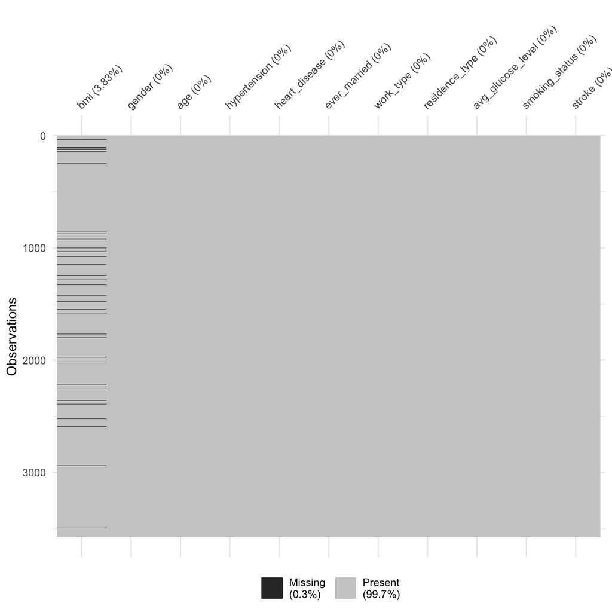

```r
# overview of missingness
stroke_train %>%
  vis_miss(sort_miss = TRUE)
```

As shown, within the 11 columns in the dataset, there is only column `bmi` with missing data. The response variable `stroke` does not have any missing values. To clearly present the percentage of missingness for each variable, we created the table below using `miss_var_summary()`, and we highlighted the rows for the variable with missing value in blue:

```r
# overview table
stroke_train %>%
  miss_var_summary() %>%
  kbl() %>%
  kable_classic() %>%
  kable_styling(bootstrap_options = c("striped", "hover")) %>%
  row_spec(1, color = "white",
           background = "blue") %>%
  kableExtra::footnote(
    general = "Number and Percentage of Missing Values in Each Variable"
  )
```

| variable | n_miss | pct_miss |
| --- | --- | --- |
| bmi | 137 | 3.830025 |
| gender | 0 | 0.000000 |
| age | 0 | 0.000000 |
| hypertension | 0 | 0.000000 |
| heart_disease | 0 | 0.000000 |
| ever_married | 0 | 0.000000 |
| work_type | 0 | 0.000000 |
| residence_type | 0 | 0.000000 |
| avg_glucose_level | 0 | 0.000000 |
| smoking_status | 0 | 0.000000 |
| stroke | 0 | 0.000000 |

Note:  
Number and Percentage of Missing Values in Each Variable

As shown, `bmi` is the only variable with missing values and its percentage of missingness is about 4%. Since the degree of missingness is very low, we plan to impute `bmi` using bagged tree imputation.

### Essential Findings

#### Outcome variable

We first performed a univariate investigation of the response variable `stroke`. The barchart below provides an overview on the distribution of `stroke` in the training set:

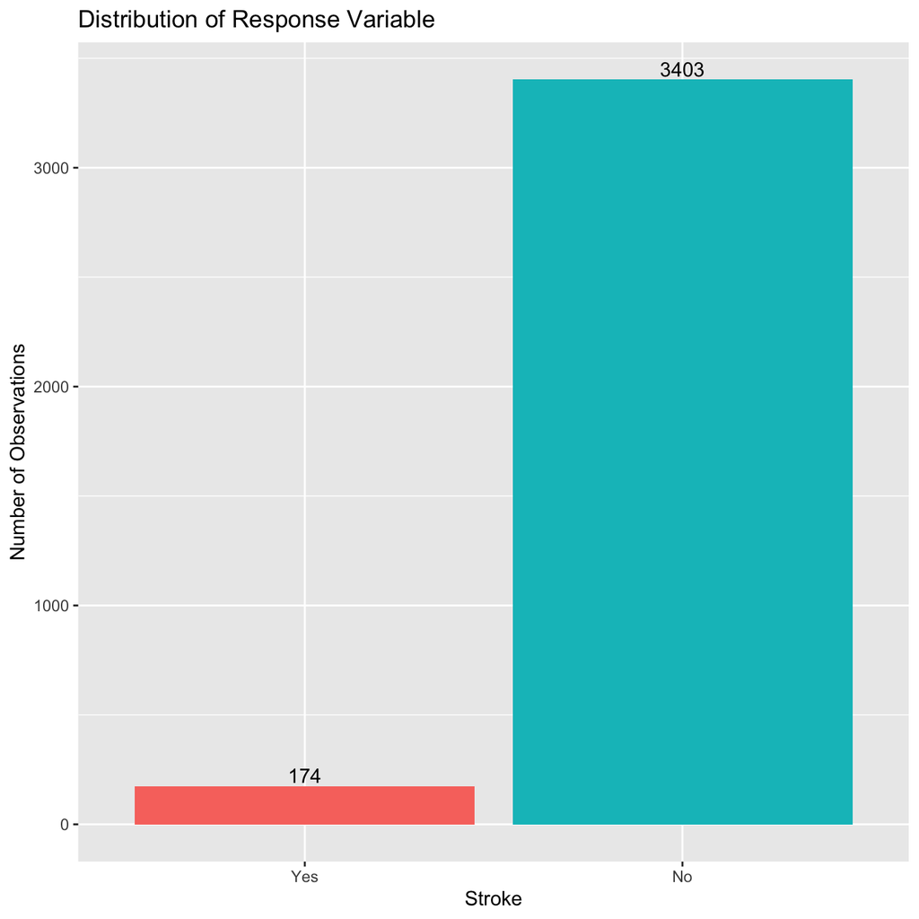

```r
# plot
stroke_train %>%
  ggplot(aes(stroke, fill = stroke)) +
  geom_bar(show.legend = FALSE) +
  labs(
    x = "Stroke",
    y = "Number of Observations",
    title = "Distribution of Response Variable"
  ) +
  geom_text(
    aes(label = ..count..),
    stat = "count",
    position = position_dodge(width = 0.9),
    vjust = -0.25
  )
```

#### Correlation among Numeric Predictors

We used a correlation plot to explore the correlation among numeric predictors. Since the degree of missingness is very low for `bmi` we temporarily dropped the `NA` in plotting to avoid errors.

[figure not shown]

```r
# correlation plot
stroke_train %>%
  select(age, avg_glucose_level, bmi) %>%

  drop_na() %>%
  # compute correlation matrix
  cor() %>%
  # visualize
  corrplot(type = "upper",
           title = "Correlations between Numeric Variables",
           mar = c(0, 0, 1, 0))
```

As shown, there is no near-perfect collinearity between any pair of number predictors. All three variables are positively related to each other. A table showing the correlation between the numeric predictors is also presented below:

```r
# correlation between predictors
stroke_train %>%
  select(age, avg_glucose_level, bmi) %>%
  drop_na() %>%
  # compute correlation matrix
  correlate() %>%
  # turn into a tibble
  stretch() %>%
  rename("correlation" = "r") %>%
  arrange(desc(correlation)) %>%
  # temporary var `row_id` to help removing repeated info
  mutate(row_id = row_number()) %>%
  # filter out even rows
  drop_na() %>%
  filter(row_id %% 2 == 0) %>%
  # remove temporary var
  select(-row_id) %>%
  kbl() %>%
  kable_classic()
```

| x | y | correlation |
| --- | --- | --- |
| bmi | age | 0.3306132 |
| avg_glucose_level | age | 0.2311689 |
| bmi | avg_glucose_level | 0.1930028 |

#### `age` predictor

In common knowledge, age is often closely related to one’s risk for stroke. Also, knowing the distribution of variable `age` in this dataset can help us understand the age range of population for which the result of this project is applicable. Thus, we plotted the distribution of `age` in the training set:

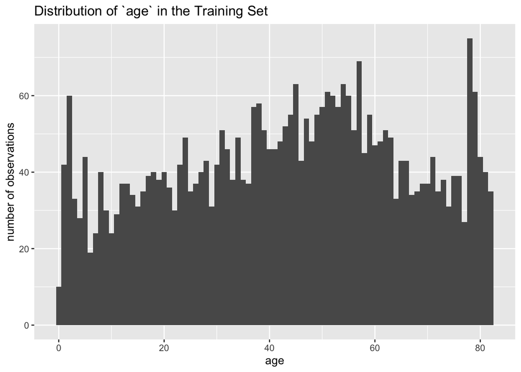

```r
# distribution of age
ggplot(stroke_train, aes(age)) +
  geom_histogram(binwidth = 1) +
  labs(
    x = "age",
    y = "number of observations",
    title = "Distribution of `age` in the Training Set"
  )
```

We then explored the relation between `age` and the outcome variable `stroke` using the boxplot below:

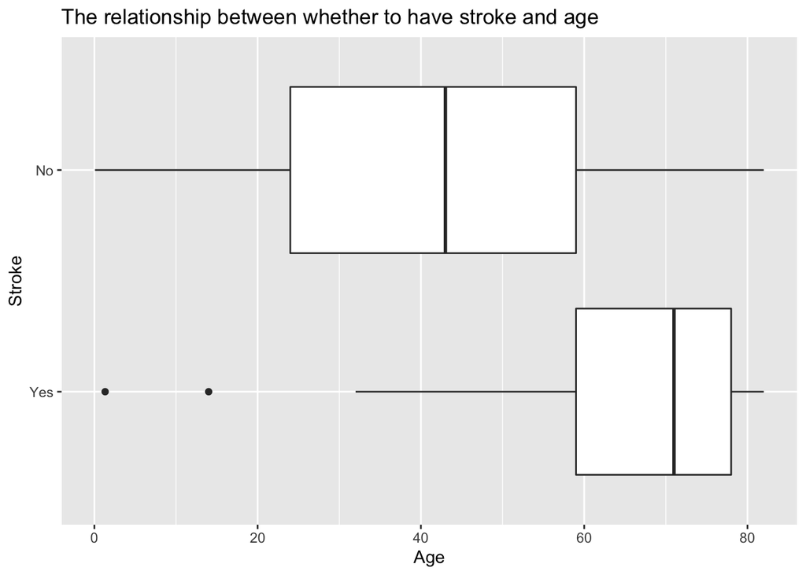

```r
# relation between `age` and `stroke`
ggplot(stroke_train, aes(age, stroke)) +
  geom_boxplot() +
  labs(
     x = "Age",
     y = "Stroke",
     title = "The relationship between whether to have stroke and age"
  )
```

#### Relation between `age` and `heart_disease`

Age is often considered as an important factor determing one’s risk for heart disease. Thus, we used boxplot to explore the relation between `age` and `heart_disease` in the training set:

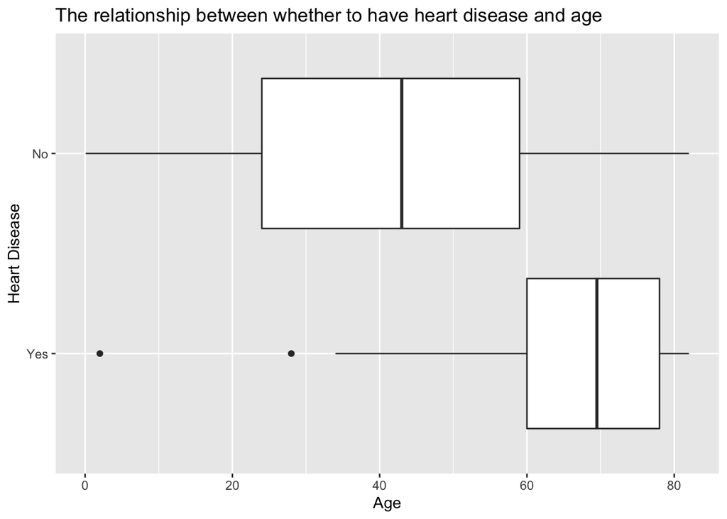

```r
# relation between `age` and `heart_disease`
ggplot(stroke_train, aes(age, heart_disease)) +
  geom_boxplot() +
  labs(
     x = "Age",
     y = "Heart Disease",
     title = "The relationship between whether to have heart disease and age"
  )
```

As shown, the distribution of `age` is severely left-skewed for `heart_disease` with level `Yes`. This visualization suggests the correlation between `heart_disease` and `age`. Among the sample population from which the data was obtained, individual older in age are more likely to get heart disease.

#### Skewness in `avg_glucose_level` and `bmi`

We also explored the distribution of `avg_glucose_level` and `bmi` in the training set:

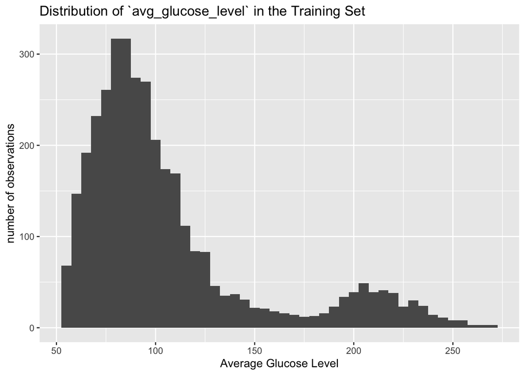

```r
# distribution of avg_glucose_level
ggplot(stroke_train, aes(avg_glucose_level)) +
  geom_histogram(binwidth = 5) +
  labs(
    x = "Average Glucose Level",
    y = "number of observations",
    title = "Distribution of `avg_glucose_level` in the Training Set"
  )
```

As shown, the distribution of `avg_glucose_level` is severely right-skewed. With the number of observations decreasing abruptly above 110. This result suggests that there are fewer observations with `avg_glucose_level` above 110. This result makes sense, considering the online resources suggest that a normal blood glucose level ranges from 80 to 140. An blood glucose level in the range 140-200 should be considered as pre-diabetes. Thus, we can imply from the plot that,in the training set, there are more observations with normal blood sugar level than observations with pre-diabetes conditions.

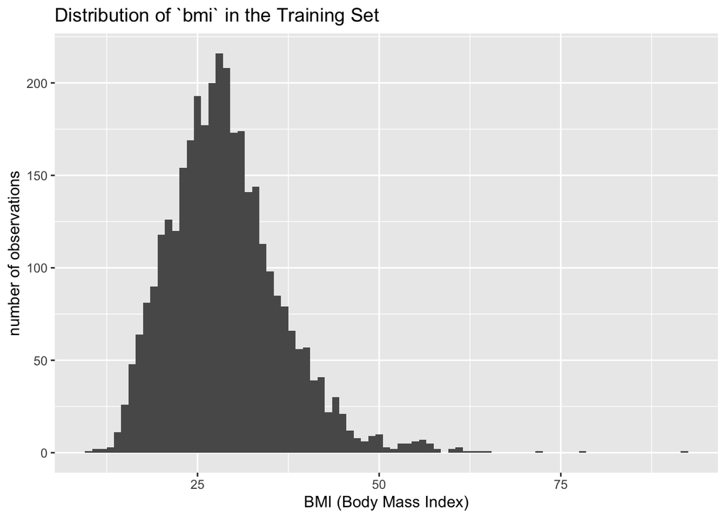

```r
# distribution of bmi
ggplot(stroke_train, aes(bmi)) +
  geom_histogram(binwidth = 1) +
  labs(
    x = "BMI (Body Mass Index)",
    y = "number of observations",
    title = "Distribution of `bmi` in the Training Set"
  )
```

As shown, the distribution of `bmi` in the training set is also severly right-skewed. There are near-zero observations for `bmi` values above 50 and values below 10. From online resources, we learned that the normal range for BMI value is 18.5 to 25. BMI values less than 18.5 suggest underweight. Values from 25.0 to 30 suggests overweight range, and BMI above 30 suggests obesity. Thus, it makes sense for the distribution of `bmi` values to peak around the range from 25 to 30.

Based on the observed skewness, we decided to log-transform variables `avg_glucose_level` and `bmi` in creating the recipes later.

#### Class Imbalance in `ever_married`

In exploring the categorical predictors, we noticed that there is class imbalance in the distributions of `ever_married`.

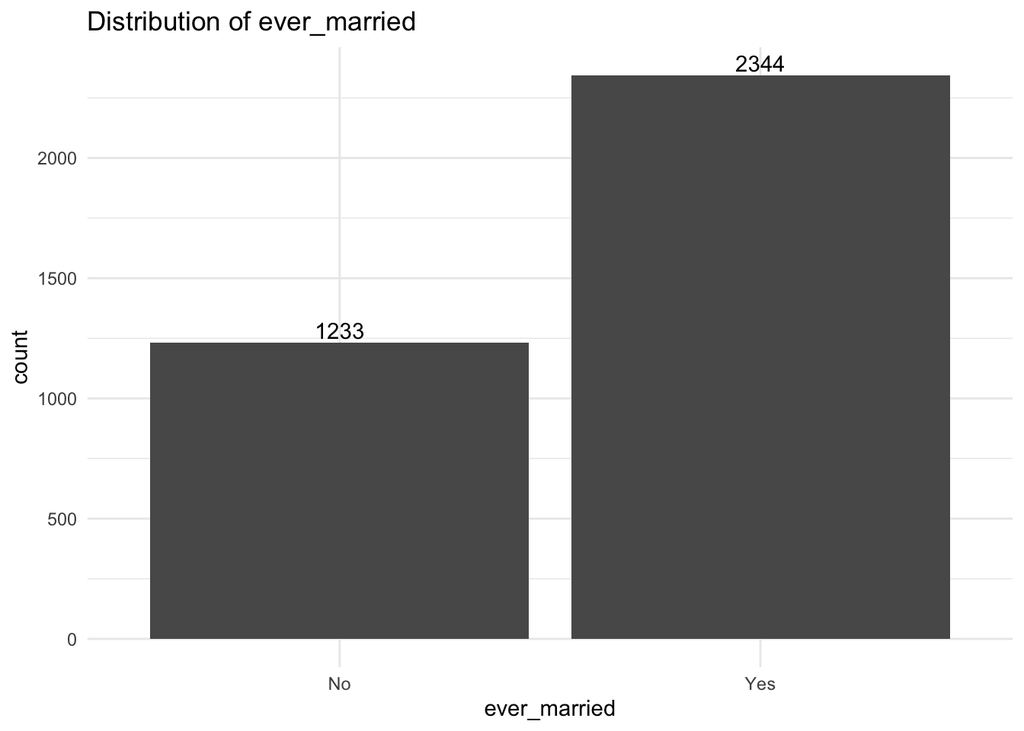

```r
ggplot(stroke_train, aes(x = ever_married)) +
  geom_bar() +
  geom_text(
    aes(label = ..count..),
    stat = "count",
    position = position_dodge(width = 0.9),
    vjust = -0.25,
    hjust = 0.5
  ) +
  labs(
    title = "Distribution of ever_married"
  ) +
  theme_minimal()
```

As shown, there are approximately 1100 more patients having married before. If encountering problem in resampling and cross-validation, we might need to consider using random under-sampling or over-sampling.

#### Less Occurring Values

Observing the distribution of the multi-level categorical variables, we noticed that some variables have severely less occuring values that might cause problems in the later modeling process. Specific recipe steps will be applied based on the situation.

##### Distribution of `gender`

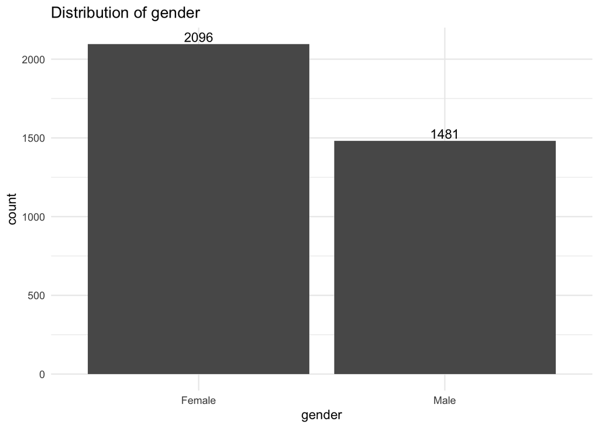

```r
ggplot(stroke_train, aes(x = gender)) +
  geom_bar() +
  geom_text(
    aes(label = ..count..),
    stat = "count",
    position = position_dodge(width = 0.9),
    vjust = -0.25,
    hjust = 0.5
  ) +
  labs(
    title = "Distribution of gender"
  ) +
  theme_minimal()
```

##### Distribution of `smoking_status`

There is also obvious difference in the number of observations in each level or variable `smoking_status`:

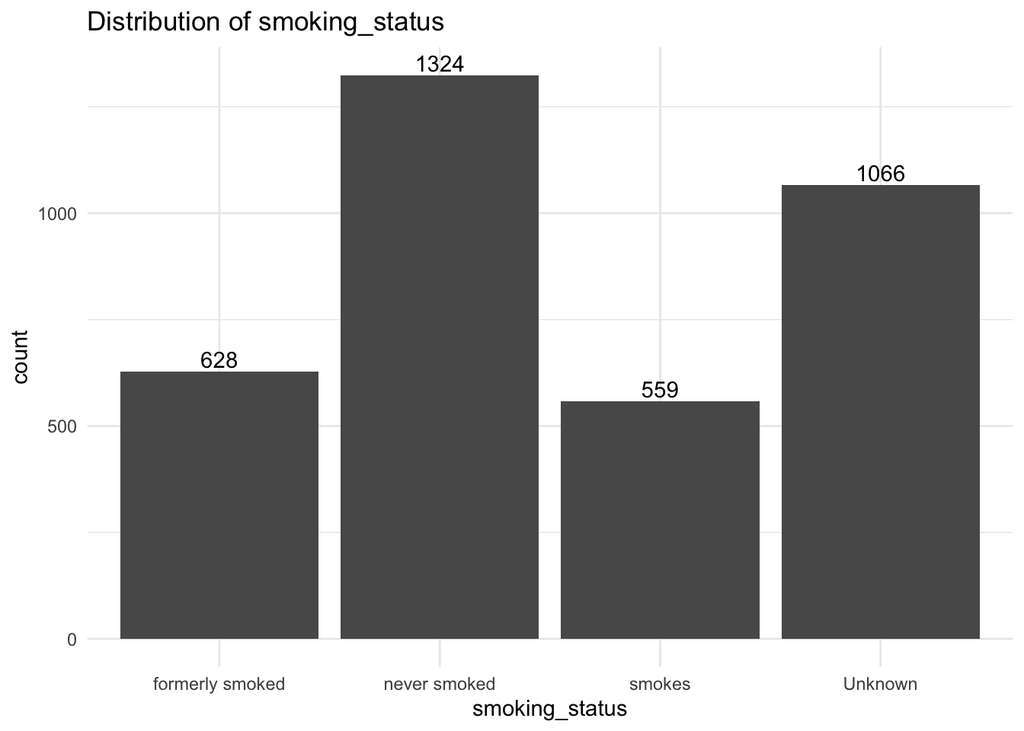

```r
ggplot(stroke_train, aes(x = smoking_status)) +
  geom_bar() +
  geom_text(
    aes(label = ..count..),
    stat = "count",
    position = position_dodge(width = 0.9),
    vjust = -0.25,
    hjust = 0.5
  ) +
  labs(
    title = "Distribution of smoking_status"
  ) +
  theme_minimal()
```

##### Distribution of `work_type`

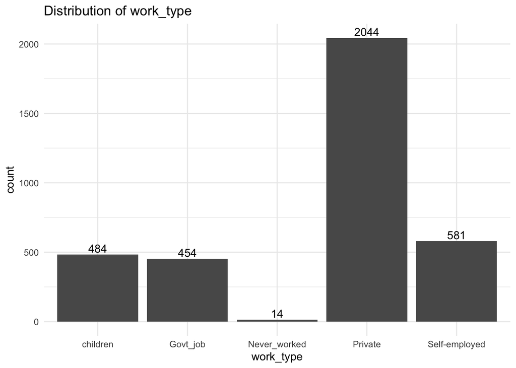

```r
ggplot(stroke_train, aes(x = work_type)) +
  geom_bar() +
  geom_text(
    aes(label = ..count..),
    stat = "count",
    position = position_dodge(width = 0.9),
    vjust = -0.25,
    hjust = 0.5
  ) +
  labs(
    title = "Distribution of work_type"
  ) +
  theme_minimal()
```

#### Relation between `gender` and `stroke`

We learned from previous readings of academic paper that the risk for stroke might differ for individuals of different gender group. Thus, we explored this relation using the training data.

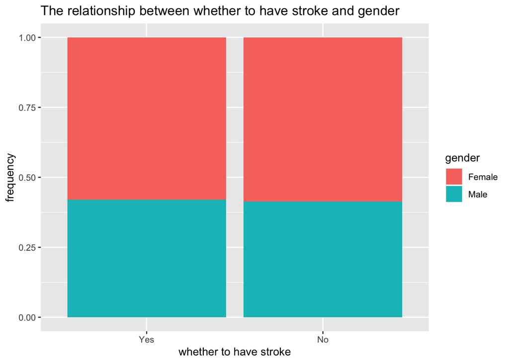

```r
ggplot(stroke_train, aes(x = stroke, fill = gender)) +
  geom_bar(position = "fill") +
  labs(
     x = "whether to have stroke",
     y = "frequency",
     title = "The relationship between whether to have stroke and gender"
  )
```

#### `stroke` and Marital & Work Status

We also explored the relation between the outcome variable `stroke` and the marital and work status of an individual.

##### `ever_married` and `stroke`

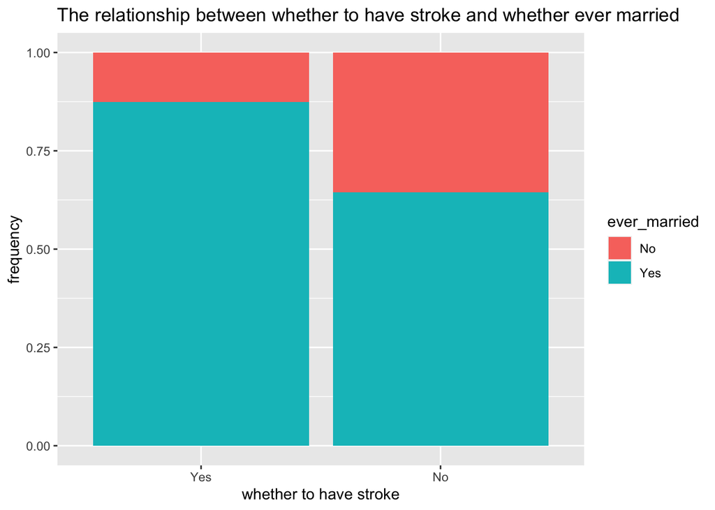

```r
ggplot(stroke_train, aes(x = stroke, fill = ever_married)) +
   geom_bar(position = "fill") +
   labs(
     x = "whether to have stroke",
     y = "frequency",
     title = "The relationship between whether to have stroke and whether ever married"
   )
```

The graph shows that the proportion of patients ever married having stroke is much higher than the proportion of patients not ever married. However, the proportion of patients ever married having stroke is higher than the proportion of patients not ever married. It might be caused by many patients have married before. Nevertheless, the huge difference between patients ever married and not ever married having stroke indicates a potential correlation between `ever_married` and `stroke`.

##### `work_type` and `stroke`

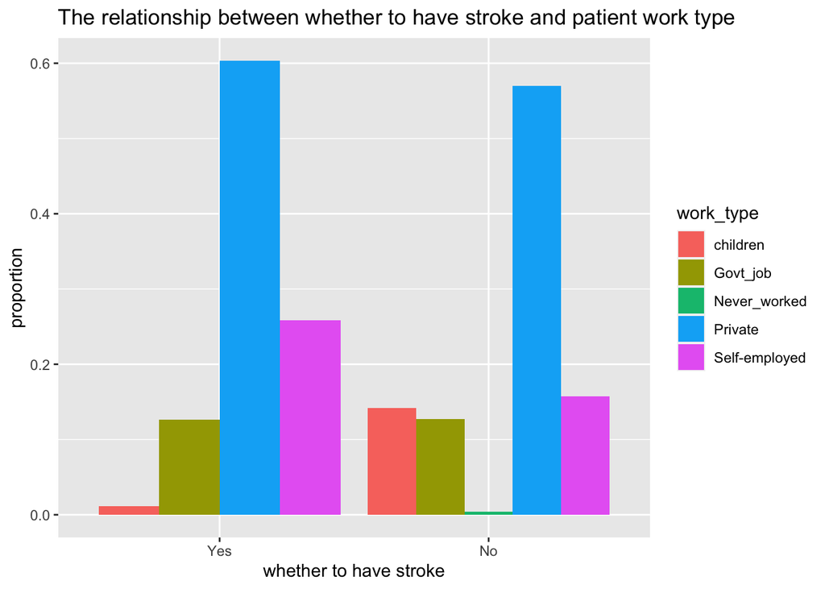

```r
stroke_train_wt <- stroke_train %>%
   group_by(stroke) %>%
   count(work_type) %>%
   mutate(wt_prop = n / sum(n))

 ggplot(stroke_train_wt, aes(x = stroke, y = wt_prop, fill = work_type)) +
   geom_col(position = "dodge") +
   labs(
     x = "whether to have stroke",
     y = "proportion",
     title = "The relationship between whether to have stroke and patient work type"
   )
```

By computing each work type proportion, the graph shows that private work type has the largest proportion in both having and not having stroke. children work type has the smallest proportion in having stroke and the third largest proportion in not having stroke. There is no people having stroke who have never worked before and there is only a tiny portion of people not having stroke who have never worked before.

### Secondary Findings

#### Distribution of `residence_type`

We plotted the distribution of `residence_type` to check for class imbalance.

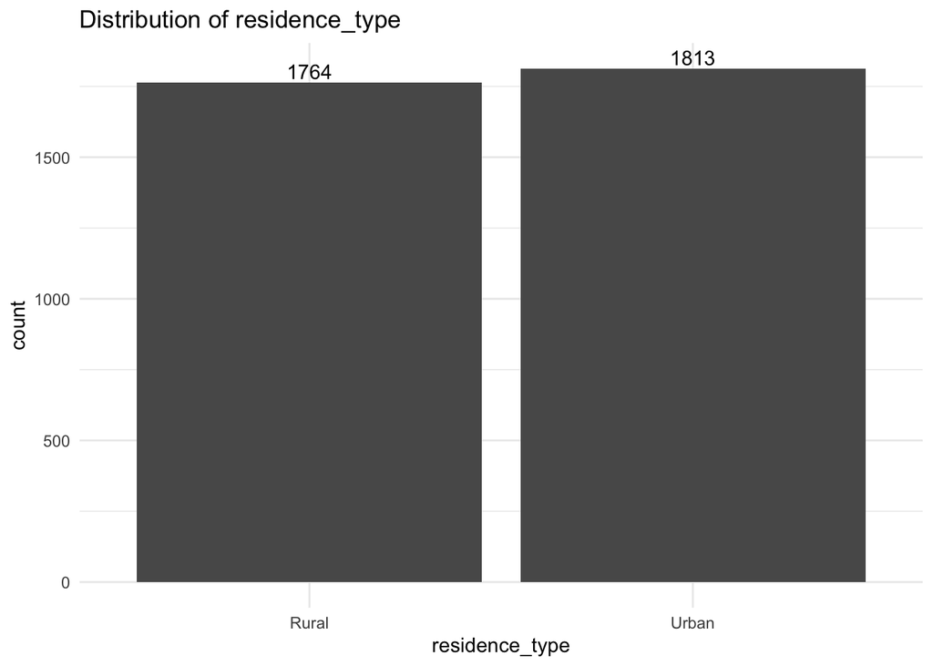

```r
ggplot(stroke_train, aes(x = residence_type)) +
  geom_bar() +
  geom_text(
    aes(label = ..count..),
    stat = "count",
    position = position_dodge(width = 0.9),
    vjust = -0.25,
    hjust = 0.5
  ) +
  labs(
    title = "Distribution of residence_type"
  ) +
  theme_minimal()
```

#### `residence_type` and `stroke`

We also explored the relation between `residence_type` and the outcome variable `stroke`:

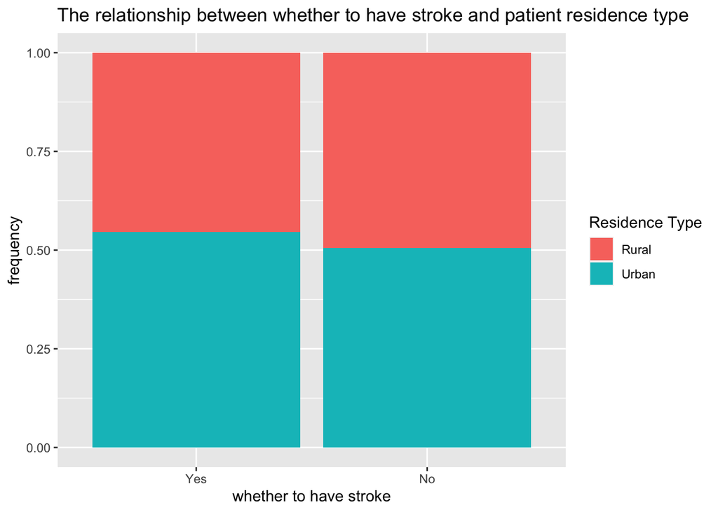

```r
ggplot(stroke_train, aes(x = stroke, fill = residence_type)) +
  geom_bar(position = "fill") +
  labs(
    x = "whether to have stroke",
    y = "frequency",
    title = "The relationship between whether to have stroke and patient residence type",
    fill = "Residence Type"
  )
```

The graph shows that there is basically no difference between whether patient lives and whether they have stroke, with people living urban area has a slightly higher chance of getting stroke.

#### `smoking_status` and `gender`

We also plotted to see the proportions of people’s smoking status in each gender:

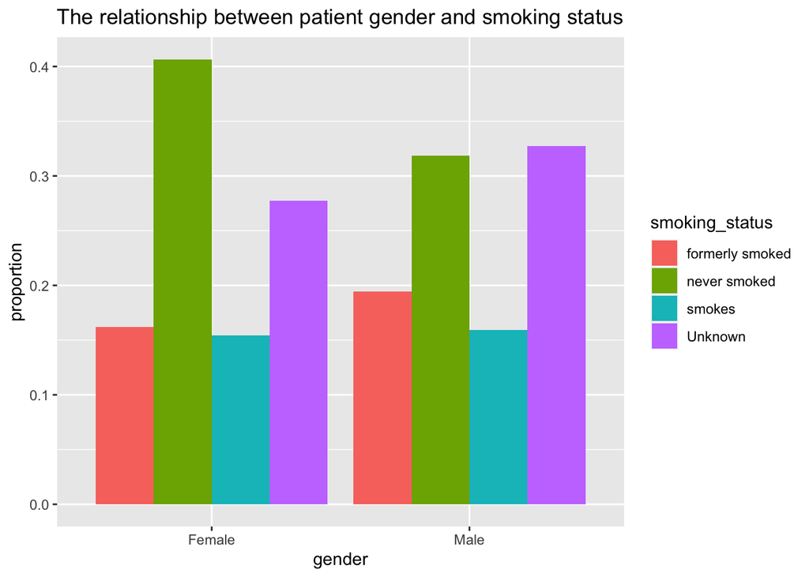

```r
stroke_stg <- stroke_train %>%
   group_by(gender) %>%
   count(smoking_status) %>%
   mutate(st_prop = n / sum(n))

 ggplot(stroke_stg, aes(x = gender, y = st_prop, fill = smoking_status)) +
   geom_col(position = "dodge") +
   labs(
     x = "gender",
     y = "proportion",
     title = "The relationship between patient gender and smoking status"
   )
```

#### `work_type` and `residence_type`

In common knowledge, residence type is associated with the type of job of an individual. Thus, we computes proportions of residence type in each work type to explore this potential relation:

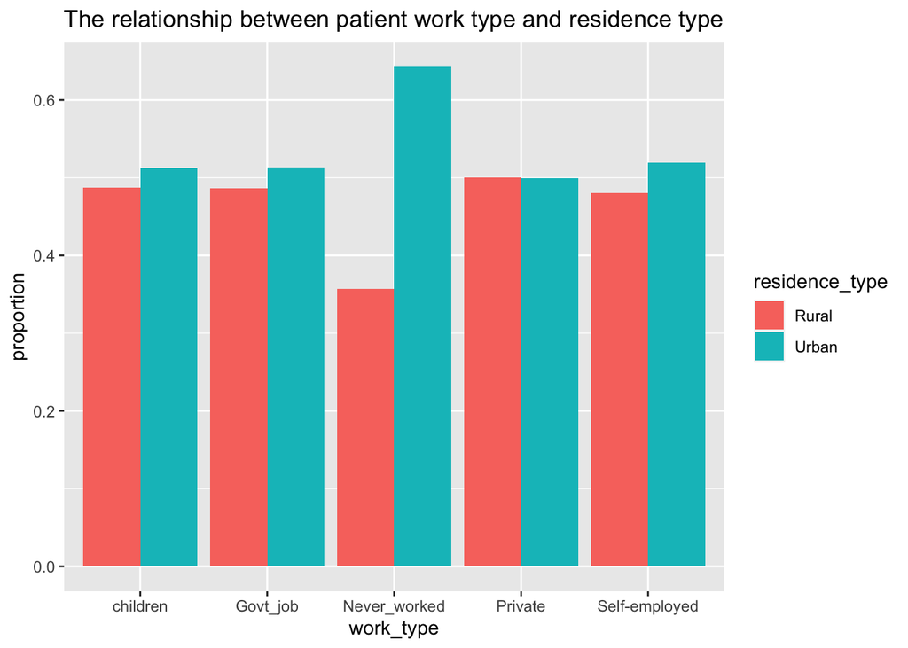

```r
 stroke_wtr <- stroke_train %>%
   group_by(work_type) %>%
   count(residence_type) %>%
   mutate(rt_prop = n / sum(n))

 ggplot(stroke_wtr, aes(x = work_type, y = rt_prop, fill = residence_type)) +
   geom_col(position = "dodge") +
   labs(
     x = "work_type",
     y = "proportion",
     title = "The relationship between patient work type and residence type"
   )
```

It can be seen that there is no strong correlation between whether patient lives and its work type. The only obvious difference is that the proportion of patients who has never worked living in urban area is much higher than living in rural area.

#### Relation between `stroke` and `avg_glucose_level`

According to common understandings, the risk for stroke is often associated with the average glucose level of an indivual. Thus, we chose to explore the relation between the outcome variable `stroke` and `avg_glucose_level` using the boxplot below:

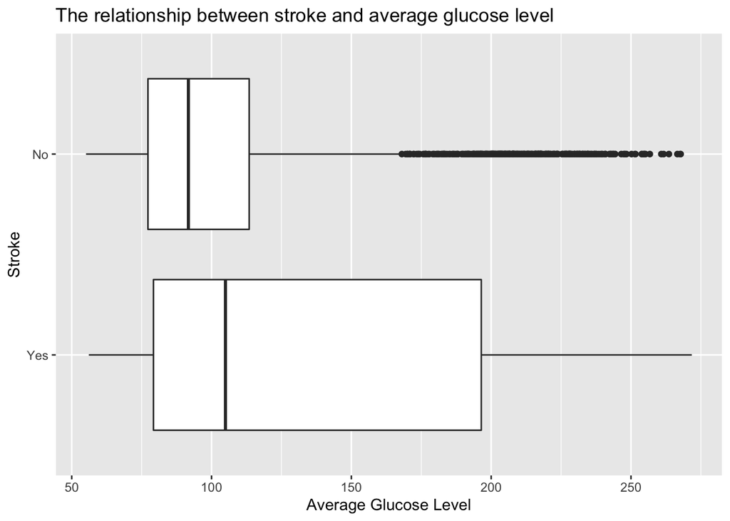

```r
# relation between `avg_glucose_level` and `stroke`
ggplot(stroke_train, aes(avg_glucose_level, stroke)) +
  geom_boxplot() +
  labs(
     x = "Average Glucose Level",
     y = "Stroke",
     title = "The relationship between stroke and average glucose level"
  )
```

### EDA Section Conclusion and Implications for Modeling

In the EDA section of our final project, we explored the distribution of the outcome variable `stroke` and the distribution of several important categorical and numeric variables using the training set of the tidied `stroke_data`. We also explored the correlation between the outcome and the predictors and the correlation between important predictors.

One important finding is the severe class imbalance in the outcome variable `stroke` after stratified sampling. After consulting the instructional team, we decided to apply random over-sampling on this variable by including `step_upsample()` as one of our recipe steps. We also included a recipe without over-sampling for comparison purpose.

Due to the observed extreme right-skewness in the distributions of `avg_glucose_level` and `bmi`, we decided to log-transform these variables in creating the recipe.

Lastly, since there are less occurring levels in categorical predictors `gender`, `smoking_status`, and `work_type`, we decided to use `step_zv()` in creating the recipe.

## Predictive Modeling

### Predictive Goal and Models of Interest

The goal of the prediction is classification, and the outcome variable is `stroke`, a categorical variable indicating whether or not the individual has stroke. Due to the severe class imbalance of the outcome variable observed in EDA, we decided to evaluate model performance based on the ROC-AUC metric.

**Six candidate models** were trained and tuned:

1. Elastic Net
   - parameters `mixture` and `penalty` are tuned
2. Nearest neighbors
   - the number of neighbors is tuned
3. Random forest
   - parameters `mtry` and `min_n` are tuned
4. Boosted tree
   - parameters `mtry`, `min_n`, and `learn_rate` are tuned
5. Support vector machine (polynomial)
   - `cost`, `degree`, and `scale_factor` are tuned
6. Multivariate adaptive regression splines (MARS)
   - parameter `num_terms` is tuned

### Load Setup and Results

```r
# Load setup
load("data/stroke_setup.rda")

# load result
load("bt_tune_orig_recipe.rda")
load("en_tune_orig_recipe.rda")
load("knn_tune_orig_recipe.rda")
load("rf_tune_orig_recipe.rda")
load("svmp_tune_orig_recipe.rda")
load("mars_tune_orig_recipe.rda")
load("bt_tune_upsample_recipe1.rda")
load("en_tune_upsample_recipe1.rda")
load("knn_tune_upsample_recipe1.rda")
load("rf_tune_upsample_recipe1.rda")
load("svmp_tune_upsample_recipe1.rda")
load("mars_tune_upsample_recipe1.rda")
```

We split the data into 70% training and 30% testing using stratified sampling on `stroke`. Then we used V-fold cross-validation with 5 folds, repeated 3 times, to fold the **training** data, we also applied stratification on the outcome variable in the cross-validation process. The code for splitting and resampling is shown below.

```r
# Split data ----
stroke_split <- initial_split(stroke_data, prop = 0.7, strata = stroke)
stroke_train <- training(stroke_split)
stroke_test <- testing(stroke_split)

## Cross-Validation ----
stroke_folds <-
  vfold_cv(data = stroke_train, v = 5, repeats = 3, strata = stroke)
```

### Model Performance Comparison

We tuned all six models on two different recipes. The difference between the recipes is that one recipe applied random over-sampling on the outcome variable `stroke`, with `over_ratio` set to 0.2. The reason for choosing 0.2 for this parameter over its default value 1 is that the difference between the two classes of `stroke` is extremely large. As shown by the visualization in the “Outcome variable” subsection of the EDA section. While there are 3403 observations with value `No` in the training set, there are only 174 observations with value `Yes`.

Since the `over_ratio` parameter is a numeric value for the ratio of the majority-to-minority frequencies. The default value 1 means that less occurring level (`Yes`) will be sampled up to have the same frequency as the most occurring level(`No`). However, if we use `over_ratio` set to 1, we will generate over 3000 observations by replicating rows of the original dataset to make the factor levels have equal frequencies. Thus, driven by the concern that “manually” replicating too many might have a negative impact on the model performance, we choose an `over_ratio` value of 0.2. The original recipe without the upsampling step and the recipe with the upsampling step are shown below:

```r
# Build recipe ----
# original recipe - no over-sampling
stroke_recipe_orig <- recipe(stroke ~ ., data = stroke_train) %>%
  step_impute_bag(bmi) %>% # bag impute bmi missing values
  step_log(avg_glucose_level, bmi) %>%
  step_interact(bmi ~ age) %>%
  step_dummy(all_nominal_predictors()) %>%
  step_zv(all_predictors()) %>%
  step_normalize(all_predictors())

# recipe with 0.2 ratio over-sampling
stroke_recipe_over_sampling_1 <- recipe(stroke ~ ., data = stroke_train) %>%
  # over-sampling, 0.2 ratio
  step_upsample(stroke, over_ratio = 0.2) %>%
  step_impute_bag(bmi) %>% # bag impute bmi missing values
  step_log(avg_glucose_level, bmi) %>%
  step_interact(bmi ~ age) %>%
  step_dummy(all_nominal_predictors()) %>%
  step_zv(all_predictors()) %>%
  step_normalize(all_predictors())
```

We tuned the models in separate R-script files. The tables below compares the tuning results cross models and cross recipes. The two main goals for the comparison are to find the best model and to explore the impact of over-sampling on model performance.

#### Optimal Model Performance

The tables showing the best performing model using the original recipe and the recipe with upsampling step are presented below:

##### Original Recipe

```r
# result tibble
tune_results_orig <- tibble(
  model_type = c("Elastic Net", "K-nearest Neighbors", "Random Forest", "Boosted Tree", "SVM Polynomial", "Multivariate Adaptive Regression Splines"),
  tune_info = list(en_tuned, nn_tuned, rf_tuned, bt_tuned,
                   svmp_tuned, mars_tuned),
  # assess model tuning results
  assessment_info = map(tune_info, collect_metrics),
  # judge models based on the accuracty metric
  best_model = map(tune_info, ~ show_best(.x, metric = "roc_auc"))
)

# tibble for tuning performance
tune_performance_orig <- tune_results_orig %>%
  select(model_type, best_model) %>%
  unnest(best_model) %>%
  group_by(model_type) %>%
  filter(mean == max(mean)) %>%
  arrange(desc(mean)) %>%
  select(model_type, mean, std_err)

# print table
tune_performance_orig %>%
  rename("ROC AUC" = mean, "Model Type" = model_type,
         "Standard Error" = std_err) %>%
  kbl() %>%
  kable_styling(bootstrap_options = c("striped", "hover", "condensed")) %>%
  row_spec(1, color = "white",
              background = "blue") %>%
  kableExtra::footnote(general = "Best Performance for 6 Candidate Models Using Original Recipe")
```

| Model Type | ROC AUC | Standard Error |
| --- | --- | --- |
| Elastic Net | 0.8386933 | 0.0065819 |
| Boosted Tree | 0.8382027 | 0.0077664 |
| Random Forest | 0.8275214 | 0.0073927 |
| Multivariate Adaptive Regression Splines | 0.8218456 | 0.0087817 |
| SVM Polynomial | 0.8032309 | 0.0077858 |
| K-nearest Neighbors | 0.6665875 | 0.0094442 |

Note:  
Best Performance for 6 Candidate Models Using Original Recipe

As shown, the best performing model using the original recipe (without over-sampling) is the Elastic Net model (highlighted in blue). The mean ROC-AUC score is 0.8386933. Nevertheless, the standard deviation is 0.0065819, while the difference between the mean ROC-AUC score of the elastic net model and mean ROC-AUC score of the second best model (Boosted Tree) is only 0.0004906. Since the difference is much smaller than the standard deviation, the Elastic Net model does not show significantly better performance than the Boosted Tree model, and they show comparative performance.

The difference between the mean ROC-AUC score of the Boosted Tree model and the third best model (Random Forest) is 0.0106813, larger than its standard deviation 0.0077664, suggesting that it shows significantly better performance. Thus, we conclude that the Elastic Net model is the best performing models using the original recipe, with mean ROC-AUC score about 0.839, while the Boosted Tree model shows comparatively good performance.

##### Upsampling Recipe

```r
# result tibble
tune_results_upsample1 <- tibble(
  model_type = c("Elastic Net", "K-nearest Neighbors", "Random Forest", "Boosted Tree", "SVM Polynomial", "Multivariate Adaptive Regression Splines"),
  tune_info = list(en_tuned_over_sampling_1, nn_tuned_over_sampling_1, rf_tuned_over_sampling_1, bt_tuned_over_sampling_1, svmp_tuned_over_sampling_1, mars_tuned_over_sampling_1),
  # assess model tuning results
  assessment_info = map(tune_info, collect_metrics),
  # judge models based on the accuracty metric
  best_model = map(tune_info, ~ show_best(.x, metric = "roc_auc"))
)

# tibble for tuning performance
tune_performance_upsample1 <- tune_results_upsample1 %>%
  select(model_type, best_model) %>%
  unnest(best_model) %>%
  group_by(model_type) %>%
  filter(mean == max(mean)) %>%
  arrange(desc(mean)) %>%
  select(model_type, mean, std_err)

# print table
tune_performance_upsample1 %>%
  rename("ROC AUC" = mean, "Model Type" = model_type,
         "Standard Error" = std_err) %>%
  kbl() %>%
  kable_styling(bootstrap_options = c("striped", "hover", "condensed")) %>%
  row_spec(1, color = "white",
              background = "blue") %>%
  kableExtra::footnote(general = "Best Performance for 6 Candidate Models Using Upsampling Recipe")
```

| Model Type | ROC AUC | Standard Error |
| --- | --- | --- |
| Elastic Net | 0.8376819 | 0.0068808 |
| Boosted Tree | 0.8330923 | 0.0056125 |
| Multivariate Adaptive Regression Splines | 0.8290459 | 0.0076066 |
| Random Forest | 0.8184530 | 0.0076372 |
| SVM Polynomial | 0.8042918 | 0.0081744 |
| K-nearest Neighbors | 0.6589469 | 0.0095028 |

Note:  
Best Performance for 6 Candidate Models Using Upsampling Recipe

As shown, for the upsampling recipe, the best performing model is also the Elastic Net model, with mean ROC-AUC score of 0.8376819. The second best model is also the Boosted Tree model. However, for this recipe, the difference between the mean ROC-AUC score of the Elastic Net model and the second best model (Boosted Tree) is 0.0045896, smaller than its standard error, which is 0.0068808. Thus, Elastic Net model is the best performing model for the recipe with over-sampling step, and it doesn’t show a significantly better performance than the second best Boosted Tree model.

#### Impact of Over-sampling

```r
# result tibble
tune_results_diff_recipe <- tibble(
  model_type = c("Elastic Net (Original Recipe)",
                 "Boosted Tree (Original Recipe)",
                 "Elastic Net (Upsampling Recipe)",
                 "Boosted Tree (Upsampling Recipe)"),
  tune_info = list(en_tuned, bt_tuned,
                   en_tuned_over_sampling_1,
                   bt_tuned_over_sampling_1),
  # assess model tuning results
  assessment_info = map(tune_info, collect_metrics),
  # judge models based on the accuracty metric
  best_model = map(tune_info, ~ show_best(.x, metric = "roc_auc"))
)

# tibble for tuning performance
tune_performance_diff_recipe <- tune_results_diff_recipe %>%
  select(model_type, best_model) %>%
  unnest(best_model) %>%
  group_by(model_type) %>%
  filter(mean == max(mean)) %>%
  arrange(desc(mean)) %>%
  select(model_type, mean, std_err)

# print table
tune_performance_diff_recipe %>%
  rename("ROC AUC" = mean, "Model Type" = model_type,
         "Standard Error" = std_err) %>%
  kbl() %>%
  kable_styling(bootstrap_options = c("striped", "hover", "condensed")) %>%
  row_spec(1, color = "white",
              background = "blue") %>%
  kableExtra::footnote(general = "Best Performance across Different Models and Different Recipes")
```

| Model Type | ROC AUC | Standard Error |
| --- | --- | --- |
| Elastic Net (Original Recipe) | 0.8386933 | 0.0065819 |
| Boosted Tree (Original Recipe) | 0.8382027 | 0.0077664 |
| Elastic Net (Upsampling Recipe) | 0.8376819 | 0.0068808 |
| Boosted Tree (Upsampling Recipe) | 0.8330923 | 0.0056125 |

Note:  
Best Performance across Different Models and Different Recipes

As shown, for both the Elastic Net model and the Boosted Tree model, the best model using the original recipe out-performs the best model using the upsampling recipe. However, the difference between the mean ROC-AUC score of different recipes of the Elastic Net model is only 0.0010114, much smaller than its standard error 0.0065819. Since this difference is not big enough to support the claim on the impact on over-sampling on model performance, we created another recipe with over-sampling step on `stroke`, and we examines the tuning results of the Elastic Net model and Boosted Tree model on this recipe. In this recipe, the `over_ratio` is set to 0.5 for comparison purpose. The recipe is shown below:

```r
# recipe with 0.5 ratio over-sampling
stroke_recipe_over_sampling_2 <- recipe(stroke ~ ., data = stroke_train) %>%
  # over-sampling, 0.5 ratio
  step_upsample(stroke, over_ratio = 0.5) %>%
  step_impute_bag(bmi) %>% # bag impute bmi missing values
  step_log(avg_glucose_level, bmi) %>%
  step_interact(bmi ~ age) %>%
  step_dummy(all_nominal_predictors()) %>%
  step_zv(all_predictors()) %>%
  step_normalize(all_predictors())
```

The results are loaded and compared with the tuning results of the Elastic Net model and the Boost Tree Model using the original and first over-sampling recipe:

```r
# load results
load("bt_tune_upsample_recipe2.rda")
load("en_tune_upsample_recipe2.rda")

# organize into table
# result tibble
tune_results_diff_recipe <- tibble(
  model_type = c("Elastic Net (Original Recipe)",
                 "Boosted Tree (Original Recipe)",
                 "Elastic Net (Upsampling Recipe (0.2 ratio))",
                 "Boosted Tree (Upsampling Recipe (0.2 ratio))",
                 "Elastic Net (Upsampling Recipe (0.5 ratio))",
                 "Boosted Tree (Upsampling Recipe (0.5  ratio))"),
  tune_info = list(en_tuned, bt_tuned,
                   en_tuned_over_sampling_1,
                   bt_tuned_over_sampling_1,
                   en_tuned_over_sampling_2,
                   bt_tuned_over_sampling_2),
  # assess model tuning results
  assessment_info = map(tune_info, collect_metrics),
  # judge models based on the accuracty metric
  best_model = map(tune_info, ~ show_best(.x, metric = "roc_auc"))
)

# tibble for tuning performance
tune_performance_diff_recipe <- tune_results_diff_recipe %>%
  select(model_type, best_model) %>%
  unnest(best_model) %>%
  group_by(model_type) %>%
  filter(mean == max(mean)) %>%
  arrange(desc(mean)) %>%
  select(model_type, mean, std_err)

# print table
tune_performance_diff_recipe %>%
  rename("ROC AUC" = mean, "Model Type" = model_type,
         "Standard Error" = std_err) %>%
  kbl() %>%
  kable_styling(bootstrap_options = c("striped", "hover", "condensed")) %>%
  row_spec(1, color = "white",
              background = "blue") %>%
  kableExtra::footnote(general = "Best Performance across two best Models with Two Different Upsampling Recipes")
```

[output not shown]

Note:  
Best Performance across two best Models with Two Different Upsampling Recipes

As shown, even though the tuning result with the oversampling step is not as good as the result without the oversampling step, the difference is very small. For the Elastic Net model the difference of the model with the 0.2 ratio upsampling recipe and the 0.5 ratio upsampling recipe in comparison to the original recipe is 0.0010114 and 0.003307, respectively. Both numbers are smaller than 0.0065819, the standard error of the result of the Elastic Net model with the original recipe (which is also the best model overall). Similarly, in Boosted Tree model, there is no significant decline in performance when the upsampling step is applied. Also, the ROC-AUC score of the model with the upsampling recipe with `over_ratio` set to 0.5 is actually higher than the ROC-AUC score of the model with the upsampling recipe with `over_ratio` set to 0.2 by 0.0006822.

Based on the observation, we concluded that there is no sufficient statistical evidence that applying over-sampling or setting `over_ratio` to a higher number will have strong negative impacts on the model performance.

#### Tuning Time

We also organized the tuning time of all models using the original recipe into a table. The row showing the model type with the shortest tuning time is highlighted in green, and the row showing the tuning time for the “best-performance model (the elastic net model)” chosen in the previous section is highlighted in blue:

```r
# result tibble
tune_time <- tibble(
  model_type = c("K-nearest Neighbors",
                 "Multivariate Adaptive Regression Splines",
                 "Elastic Net", "SVM Polynomial",
                 "Random Forest", "Boosted Tree"),
  tuning_time = list(41.969, 43.295, 47.477, 101.668, 411.727, 844.824))

# print tibble
tune_time %>%
  inner_join(tune_performance_orig %>% select(c(model_type, mean))) %>%
  rename("ROC AUC" = mean, "Model Type" = model_type,
         "Tuning Time" = tuning_time) %>%
  kbl() %>%
  kable_styling(bootstrap_options = c("striped", "hover", "condensed")) %>%
  row_spec(3, color = "white",
              background = "blue") %>%
  row_spec(1, color = "white",
              background = "green") %>%
  kableExtra::footnote(general = "Run time for the tuning process for the 6 model types")
```

| Model Type | Tuning Time | ROC AUC |
| --- | --- | --- |
| K-nearest Neighbors | 41.969 | 0.6665875 |
| Multivariate Adaptive Regression Splines | 43.295 | 0.8218456 |
| Elastic Net | 47.477 | 0.8386933 |
| SVM Polynomial | 101.668 | 0.8032309 |
| Random Forest | 411.727 | 0.8275214 |
| Boosted Tree | 844.824 | 0.8382027 |

Note:  
Run time for the tuning process for the 6 model types

As shown, the tuning run time for the Boosted Tree model is the longest, and it takes 844.824 seconds. The tuning run time for the Nearest Neighbors model is the shortest, and it takes 41.969 seconds. The model type with the best performance, the elastic net model, has a tuning run time of 47.477 seconds, which is the third shortest among all models.

### Best Model

According to the previous section, the best model overall is the Elastic Net model with the original recipe. We printed the parameter combination for the elastic net model that yields the best performance. The row showing the parameter set with the optimal “ROC-AUC” value is highlighted in blue:

```r
# elastic net model
show_best(en_tuned, metric = "roc_auc") %>%
  select(-.config) %>%
  kbl() %>%
  kable_styling(bootstrap_options = c("striped", "hover", "condensed")) %>%
  row_spec(1, color = "white",
              background = "blue") %>%
  kableExtra::footnote(general = "Tuning Result for Elastic Net Model")
```

| penalty | mixture | .metric | .estimator | mean | n | std_err |
| --- | --- | --- | --- | --- | --- | --- |
| 0.0031623 | 1.00 | roc_auc | binary | 0.8386933 | 15 | 0.0065819 |
| 0.0031623 | 0.75 | roc_auc | binary | 0.8384658 | 15 | 0.0065810 |
| 0.0031623 | 0.50 | roc_auc | binary | 0.8380563 | 15 | 0.0064989 |
| 0.0031623 | 0.25 | roc_auc | binary | 0.8373764 | 15 | 0.0063792 |
| 0.0000000 | 0.00 | roc_auc | binary | 0.8363827 | 15 | 0.0062959 |

Note:  
Tuning Result for Elastic Net Model

As shown, the best performance model is the elastic net model with parameter `penalty` equals 0.0031623 and parameter `mixture` equals 1.00.

### Visualization of Tuning Results

Since the elastic net model and the boosted tree model are shown to be the two best candidate model types, we used `autoplot()` to examine the tuning result of these model types with the original recipe (without oversampling):

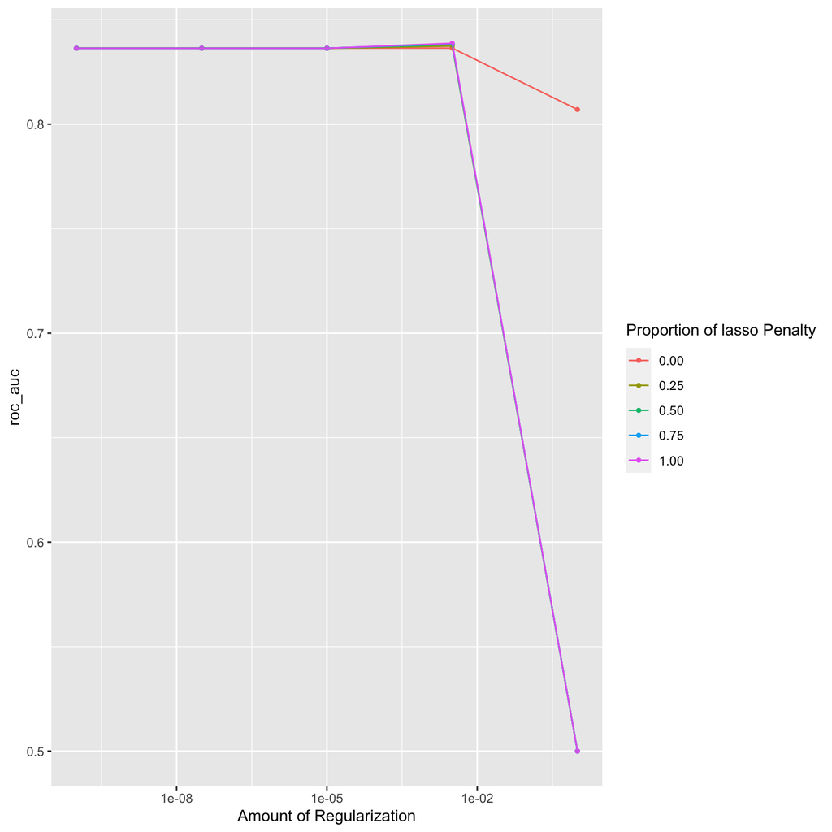

```r
autoplot(en_tuned, metric = "roc_auc")
```

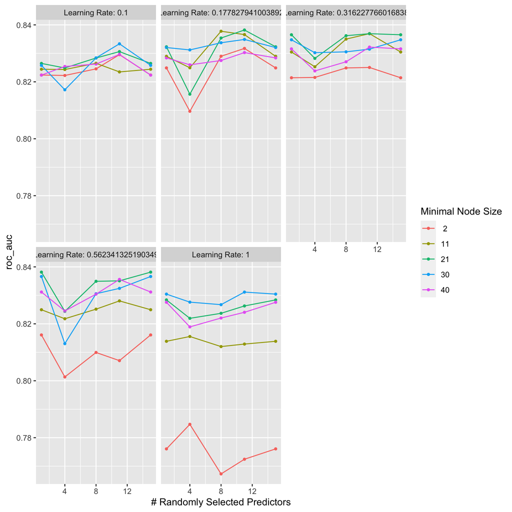

```r
autoplot(bt_tuned, metric = "roc_auc")
```

As shown, for the elastic net model, the ROC-AUC value flattens at a value slightly under 0.84 for parameter combinations with all different `mixture` values and `penalty` values below 0.01. The ROC-AUC value shows an obvious drop for `penalty` values greater than 0.01 for all different `mixture` values. The highest ROC-AUC value is obtained for the `mixture` value of 1 and the `penalty value` around 0.003.

### Fit Entire Training Set

We then fit the winning model to the entire training set:

```r
en_workflow_tuned <- en_workflow %>%
  finalize_workflow(select_best(en_tuned, metric = "roc_auc"))

en_results <- fit(en_workflow_tuned, stroke_train)
```

### Fit Testing Set

To examine the chosen model’s performance on the brand-new, untouched testing dataset, we used `predict()`, `bind_cols()`, and `metric_set()` to fit the tuned model to the `stroke_test`. We looked at both the ROC-AUC and accuracy metrics.

```r
# create metric set
stroke_metrics <- yardstick::metric_set(yardstick::roc_auc,
                                       yardstick::accuracy)

# show result of prediction on testing data
predict(en_results, new_data = stroke_test) %>%
  bind_cols(stroke_test %>% select(stroke)) %>%
  bind_cols(predict(en_results,
                    new_data = stroke_test, type = "prob")) %>%
  stroke_metrics(truth = stroke,
                 estimate = .pred_class, .pred_Yes) %>%
  kbl() %>%
  kable_styling(bootstrap_options = c("striped", "hover", "condensed"))
```

| .metric | .estimator | .estimate |
| --- | --- | --- |
| accuracy | binary | 0.9510763 |
| roc_auc | binary | 0.8508733 |

As shown, applying the winning model on the test set, the accuracy score is 0.9510763, the model correctly classified the stroke risk for 95.1% of the individuals in the testing dataset. However, due to the severe class imbalance in the outcome variable `stroke`, judging the model performance based on this accuracy metric might be misleading.

The ROC-AUC metric when fitting the model to the test set is 0.8508. The ROC-AUC metric provides an insight into the model’s capability at distinguishing between classes, and it is indifferent to the class imbalance. The ROC-AUC value of 0.8508 is slightly higher than the best value gained in tuning, which is 0.8386933. This result suggests that the model performs pretty well on the new data.

The ROC-AUC curve is plotted below as a reference.

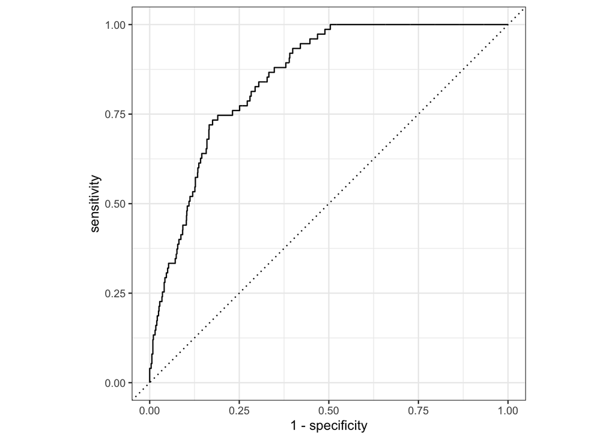

```r
# generate predictions
best_model_pred <-
  predict(en_results, new_data = stroke_test) %>%
  bind_cols(stroke_test %>% select(stroke)) %>%
  bind_cols(predict(en_results,
                    new_data = stroke_test, type = "prob"))
# create ROC curve
stroke_curve <-
  roc_curve(best_model_pred, truth = stroke, .pred_Yes)
# plot ROC curve
autoplot(stroke_curve)
```

### Discussion and Future Direction

Judging by the ROC-AUC metric, the elastic net model is the winning model type for all different recipes considered. The highest ROC-AUC metric value in tuning is 0.8386933. From [online resources](https://corporatefinanceinstitute.com/resources/knowledge/other/elastic-net/), we learned that the elastic net model performs well when there are groups of correlated independent variables in the dataset. This explanation relates to our findings in the EDA section. In the EDA section, we noted that variable `age` is clearly correlated `heart_disease` (plot included in earlier section). In common knowledge, age is an important factor impacting the health status of an individual. Also, many health factors, such as average glucose level, bmi, and smoking status are correlated in common understanding. However, due to time restriction, we did not have time to fully explore these correlations in the EDA section. To better understand why the elastic net model is the winning model type, future studies can be done to thoroughly assess the degree of correlation between the independent variables in the dataset.

Although the ROC-AUC values for the same model using recipe with over-sampling and recipe without over-sampling are not exactly the same, the difference is generally small for most model types. Looking at online documentations, we learned that some operations can be performed to actually tune the `over_ratio` parameter to improve model performance. Thus, tuning `over_ratio` can be a direction for future implications.

Another direction can be to examine whether all types of models are impacted in the same way by over-sampling. Organizing the results, we noticed that the ROC-AUC value for the MARS (Multivariate Adaptive Regression Splines) model is actually higher using the recipe with the over-sampling step. Therefore, it is worth investigating the reason behind this “improvement” for this specific model type.

Lastly, from the discussion with the instructional team, we learned that there are multiple methods handling the class imbalance issue besides over-sampling. For example, we can use random under-sampling. However, each methods have their own pros and cons. For example, since over-sampling is to duplicate random records from the minority class, it can lead to overfishing. In comparison, under-sampling involves removing random records from the majority class, which can cause loss of information. In the future, we can keep exploring the trade-off between different methods of solving the problem of class imbalance.

## Conclusion

This project focuses on data modeling and analysis of the “Stroke Prediction Dataset” provided on [Kaggle](https://www.kaggle.com/fedesoriano/stroke-prediction-dataset). The data documents the stroke risk and the relevant health data for individual patients.

The goal of the project is to determine whether a patient will have stroke (indicated by the `stroke` variable) based on input parameters like gender, age, related diseases, body mass index (bmi), and smoking status. The predictive goal of this project is classification.

The EDA section discovered the severe class imbalance in the outcome varible and several categorical predictors, the skewness of a few numeric predictors, and the presence of small size missingness. Based on the findings, stratified sampling is used. Also, recipe steps for imputation, log-transformation, and over-sampling steps are considered in the following modeling section.

The predictive modeling section trained and tuned six types of models for classification prediction. To explore the impact of over-sampling, three different recipes are examined: the recipe without upsampling step, the recipe with upsampling `over_ratio` set to 0.2, and the recipe with upsampling `over_ratio` set to 0.5. Among all the recipe-model combinations tried, the elastic net model with the original recipe (without oversampling) shows the highest ROC-AUC metric 0.8386933, and it is chosen to be the winning model. The chosen model is then fit to the entire training set and the test set afterwards for final assessment of its performance. Using the testing set, the model has a ROC-AUC value of 0.8508733, and an accuracy value of 0.9510763. The model’s performance in predicting the brand-new test set is adequate judging from the ROC-AUC value, since it correctly distinguishes the classes for 85% of the input data samples.

Based on the results, observations, and limitations of the current project, future studies can be conducted to further assess the impact of over-sampling methods on model performance, to better understand the correlations between independent variables, and to keep exploring different methods for solving the problem of class imbalance.

## Github Link

https://github.com/lilyyan2023/STAT301-3FinalProject